# 3. model

**3. Using your logic from above, build a model (heuristic/statistical/ML) to classify engaged and unengaged users.**

a. Note that features which are directly correlated with your target metric could lead to overfitting

## Description

My ML model will be classifying if customer will be engaged or unengaged.  
Due to the specific of available data I'm treating the last period of transactions (3 weeks), as a future period (my target), and previously available not overlapping period (previous 3 weeks) as a current period.

I'm not going to focus on feature engineering, rather prepare some basic features and try to build good quality ML model that I understand.

# Prepare data

```python
import pandas as pd
import pandasql
import numpy as np
import feather

from dateutil import parser
from datetime import datetime
import datetime
import matplotlib.dates as mdates
import matplotlib.ticker as mtick

import matplotlib.pyplot as plt
import seaborn as sns
import matplotlib.gridspec as gridspec
import matplotlib as mpl
from matplotlib.ticker import FuncFormatter

pd.options.display.max_rows = 999
pd.options.display.max_columns = 999

seed = 1234
```

```python
%%time
users = pd.read_csv("../_raw_data/rev-users.csv", parse_dates = ['created_date'])
notifications = pd.read_csv("../_raw_data/rev-notifications.csv", parse_dates = ['created_date'])
transactions = pd.read_csv("../_raw_data/rev-transactions.csv", parse_dates = ['created_date'])
devices = pd.read_csv("../_raw_data/rev-devices.csv")
```

```
CPU times: user 9.86 s, sys: 1.11 s, total: 11 s
Wall time: 18.5 s
```

```python
engagement_data = feather.read_dataframe("./../data/engagement_data.feather")
```

## Analysis assumption

Due to my metric specify, which is based on transactions, the moment in time when we measure customers engagement is very important.  
The latest transaction data in dataset (around 2019-05-15) are unstable - the number of transactions per day is decreasing unnaturally. That's why I’ve decided to measure engagement a bit earlier - on the first of May 2019.

```python
analysis_date = engagement_data.created_date.max()
analysis_date_m_3w = (analysis_date-datetime.timedelta(days=22))
analysis_date = engagement_data.created_date.max()
```

```python
analysis_date, analysis_date_m_3w
```

```
(Timestamp('2019-05-01 00:00:00'), Timestamp('2019-04-09 00:00:00'))
```

### Question: Given that customer is engaged, what is the chance that will stay engaged ??

```python
eng_ot = engagement_data.groupby(['user_id','created_date']).eng_use3lastweeks.sum().unstack().reset_index()
eng_ot.columns=['user_id', 'prevoious_eng_20190409', 'current_eng_20190501']
def engagement_level(x):
    return sum(x)/len(x)
def count(x):
    return len(x)
def True_(x):
    return sum(x)
def False_(x):
    return count(x)-True_(x)

eng_ot.groupby('prevoious_eng_20190409').aggregate({'current_eng_20190501':[count,True_,False_,engagement_level]})
```

| prevoious_eng_20190409 | current_eng_20190501 count | current_eng_20190501 True_ | current_eng_20190501 False_ | current_eng_20190501 engagement_level |
| --- | --- | --- | --- | --- |
| False | 13817 | 1289 | 12528 | 0.093291 |
| True | 4572 | 3219 | 1353 | 0.704068 |

We could assume that it's a strong correlation between engagement status now and in the past.

# prepare data

## basic feature engineering

I need to prepare data to feed my ML model.

### users

```python
users.head(3).T
```

|  | 0 | 1 | 2 |
| --- | --- | --- | --- |
| user_id | user_0 | user_1 | user_2 |
| birth_year | 1989 | 1975 | 1987 |
| country | PL | GB | PL |
| city | Gdansk | London | Poznań |
| created_date | 2018-01-13 05:15:15.599466 | 2018-01-29 03:38:46.676876 | 2018-01-18 19:17:31.229096 |
| user_settings_crypto_unlocked | 1 | 0 | 0 |
| plan | STANDARD | STANDARD | STANDARD |
| attributes_notifications_marketing_push | 1 | NaN | 0 |
| attributes_notifications_marketing_email | 1 | NaN | 0 |
| num_contacts | 3 | 21 | 21 |
| num_referrals | 0 | 0 | 0 |
| num_successful_referrals | 0 | 0 | 0 |

**Cooperation time**: newest available transaction record in dataset **-** user create date.

```python
users = users.assign(cooperation_time = lambda x: x['created_date'].apply(lambda x: (analysis_date-x).days))
```

### Devices

Devices associated with a user

```python
len(devices.user_id.unique())==len(users.user_id.unique())
users = users.merge(devices, on = ['user_id']).rename(columns={'brand':'device_brand'})
```

### Notyfications

```python
notifications.query("user_id == 'user_0'")
```

|  | reason | channel | status | user_id | created_date |
| --- | --- | --- | --- | --- | --- |
| 7785 | REENGAGEMENT_ACTIVE_FUNDS | PUSH | SENT | user_0 | 2018-10-31 22:49:57.304466 |
| 25566 | REENGAGEMENT_ACTIVE_FUNDS | PUSH | SENT | user_0 | 2019-02-13 00:00:36.630466 |
| 28429 | REENGAGEMENT_ACTIVE_FUNDS | PUSH | SENT | user_0 | 2018-12-11 00:04:29.521466 |
| 30270 | FIFTH_PAYMENT_PROMO | EMAIL | SENT | user_0 | 2019-02-01 21:06:09.303466 |
| 33871 | FIFTH_PAYMENT_PROMO | PUSH | SENT | user_0 | 2019-02-01 21:06:09.340466 |
| 46418 | JOINING_ANNIVERSARY | PUSH | SENT | user_0 | 2019-01-12 21:09:29.655466 |
| 50550 | BLACK_FRIDAY | PUSH | SENT | user_0 | 2018-11-25 02:44:44.635466 |
| 61326 | METAL_GAME_START | EMAIL | SENT | user_0 | 2019-02-26 22:43:09.491466 |

Last notification send to user: resone, channel, status (in period that I'm treating as a current period)

```python
last_notification = notifications.query("status=='SENT' & created_date < '{}'".format(analysis_date_m_3w.strftime("%Y-%m-%d"))).\
    sort_values('created_date', ascending=True).groupby('user_id').tail(1)[['user_id','reason','channel']].copy()
last_notification.columns = ['user_id','not_last_reason','not_last_channel']
```

```python
users = users.merge(last_notification, how='left', on=['user_id'] )
```

## Egagament

```python
users = users.merge(
    engagement_data.\
        query("created_date == '{}'".format(analysis_date.strftime("%Y-%m-%d"))).\
        reset_index(drop=True)[['user_id','eng_use3lastweeks']]
    ,on=['user_id']
    ,how='inner'
).reset_index(drop=True)

users.eng_use3lastweeks = users.eng_use3lastweeks*1
```

I'm building feature that indicates if customer is engaged in first available period that is not overlap with my target (here it's 3 weeks earlier).

In reality I will have an information if customer is engaged now and I would try to predict if he will be engaged in the next period.

```python
users_prev_true = users.merge(engagement_data.query("created_date=='2019-04-09' and eng_use3lastweeks")[['user_id']],
            on='user_id', how='inner')
users_prev_false = users.merge(engagement_data.query("created_date=='2019-04-09' and not eng_use3lastweeks")[['user_id']],
            on='user_id', how='inner')

users_prev_true['was_engaged'] = True
users_prev_false['was_engaged'] = False
users = pd.concat([users_prev_true,users_prev_false]).sort_values('user_id').reset_index(drop=True)
```

### Train/ test/ validation split

```python
from sklearn.model_selection import train_test_split
```

I'm spliting the data (randomly) acording to the fallowing:

**Training Dataset**: The sample of data used to fit the model. (70%)  
**Validation Dataset**: The sample of data used to provide an unbiased evaluation of a model fit on the training dataset while tuning model hyperparameters. The evaluation becomes more biased as skill on the validation dataset is incorporated into the model configuration. (10%)  
**Test Dataset**: The sample of data used to provide an unbiased evaluation of a final model fit on the training dataset. (20%)

```python
train_X, test_X, train_y, test_y = train_test_split(
    users.drop(['eng_use3lastweeks'], axis=1),
    users['eng_use3lastweeks'].tolist(), test_size=0.3, random_state=666)
```

```python
valid_X, test_X, valid_y,test_y, = train_test_split(
    test_X,
    test_y, test_size=0.66, random_state=666)
```

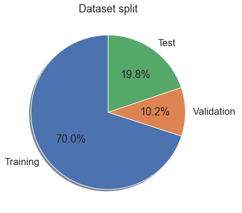

```python
sns.set(font_scale=1.5)

# Pie chart
labels = ['Training', 'Validation ', 'Test']
sizes = [train_X.shape[0],valid_X.shape[0], test_X.shape[0]]
# only "explode" the 2nd slice (i.e. 'Hogs')
fig1, ax1 = plt.subplots(figsize=(10,6))
ax1.pie(sizes,  labels=labels, autopct='%1.1f%%',
        shadow=True, startangle=90)

plt.title('Dataset split')

plt.show()
```

# ML model, LightGBM

When I have no constraints, LightGBM as my first ML model choice.  
It has very low input data requirements: no need to fill missing values, normalize data or get rid of correlations between features - obviously all that, on some reasonable level, each of mentioned abov is rather not desirable.  
But most of all its really fast and powerfull model.

```python
import numpy as np
from category_encoders import *

from sklearn.feature_extraction.text import TfidfVectorizer
from sklearn.compose import ColumnTransformer
from sklearn.pipeline import make_pipeline
from sklearn import metrics

import lightgbm as lgb
```

Since in sklearns ColumnTransformer 'passthrough' method doesn;t support column names I need to prepare my own

```python
from sklearn.base import TransformerMixin, BaseEstimator

class PassthroughTransformer(BaseEstimator, TransformerMixin):
    """Passthrough data unchanged and supports 'get_feature_names' method.."""

    def fit(self, X, y=None):
        self.columnNames = X.columns
        print( X.columns)
        return self

    def transform(self, X):
        return X

    def get_feature_names(self):
        return self.columnNames
```

I'm preparing data pipeline.  
I've removed geographical data such as Country and City, because it's tends to overfit model.

A comment on data transformation method:

- PassthroughTransformer - just pass through numeric data unchanged,
- WOEEncoder - converts categorical data to its Weight of Evidence value,

```python
np.random.seed(666)

pipe = ColumnTransformer([
        ('num',PassthroughTransformer(),['birth_year'
                              ,'attributes_notifications_marketing_push'
                              ,'attributes_notifications_marketing_email'
                              ,'num_contacts'
                              ,'num_referrals'
                              ,'num_successful_referrals'
                              ,'cooperation_time'
                             ]),
        ('te', WOEEncoder(), ['was_engaged','device_brand','plan','not_last_reason','not_last_channel']),

    ])
```

```python
train_X_t = pipe.fit_transform(train_X, train_y)
valid_X_t = pipe.transform(valid_X)
test_X_t = pipe.transform(test_X)
```

```
Index(['birth_year', 'attributes_notifications_marketing_push',
       'attributes_notifications_marketing_email', 'num_contacts',
       'num_referrals', 'num_successful_referrals', 'cooperation_time'],
      dtype='object')
```

**A comment on hyperparameter selection**:  
It's possible to use an automatic hyperparameter tuner like NNI or scikit-opt, but here is rather redundant and I've decied to use trial and errors method and set parameters from hand.  
Belove some justification about parameters selections:

- boosting_type - traditional Gradient Boosting Decision Tree,
- feature_fraction - fraction of features that are randomly selected in each iteration, the lower the more it prevents from strongest features domination,
- learning_rate - a learning rate, just try few to find out what works the best (typically between 0.1 and 0.001),
- max_bin - max number of bins features values will be bucketed in, if small training is faster but less accurate,
- max_depth - tree max depth, the higher, the more is model prone to overfit,
- n_estimators - generally could be large - I'm using early stopping anyway,
- reg_alpha and reg_lambda - regularization factor, when number of features are low it could promote the strongest features and under valuate weaker features,
- subsample - make training faster by reducing the number of data in each iteration,

```python
params = {'boosting_type':'gbdt',
          'feature_fraction': 0.5, #feature_fraction
          'learning_rate': 0.001,
          'max_bin': 400,
          'max_depth': 50,
          'n_estimators': 500, #num_iterations
          'reg_alpha': 0, #lambda_l1
          'reg_lambda': 0.1, #lambda_l2
          'subsample': 1, #bagging_fraction
         }
model = lgb.LGBMClassifier(random_state=666, **params)
```

```python
model.fit(
    X=train_X_t
    ,y=train_y
    ,eval_set = [(train_X_t,train_y),(valid_X_t,valid_y)]
    ,eval_names = ['train','valid']
    ,eval_metric = 'auc'
    ,early_stopping_rounds = 30
    ,verbose=False
    ,feature_name=pipe.get_feature_names()

)
```

```
LGBMClassifier(boosting_type='gbdt', class_weight=None, colsample_bytree=1.0,
               feature_fraction=0.5, importance_type='split',
               learning_rate=0.001, max_bin=400, max_depth=50,
               min_child_samples=20, min_child_weight=0.001, min_split_gain=0.0,
               n_estimators=500, n_jobs=-1, num_leaves=31, objective=None,
               random_state=666, reg_alpha=0, reg_lambda=0.1, silent=True,
               subsample=1, subsample_for_bin=200000, subsample_freq=0)
```

I'm using early stopping. It's prevented model overfitting by stopping training process when AUC on training set getting to rise, while AUC on valid set is not.

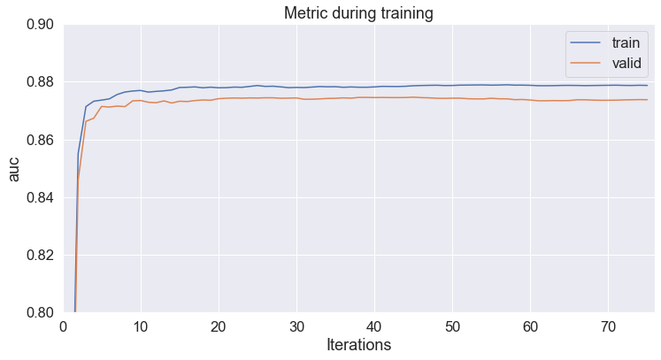

```python
fig, ax1 = plt.subplots(figsize=(12,6))

lgb.plot_metric(
    model
    ,metric='auc'
    ,ax=ax1
    ,ylim=(0.8,0.9)
)
```

Feature importance plot - below

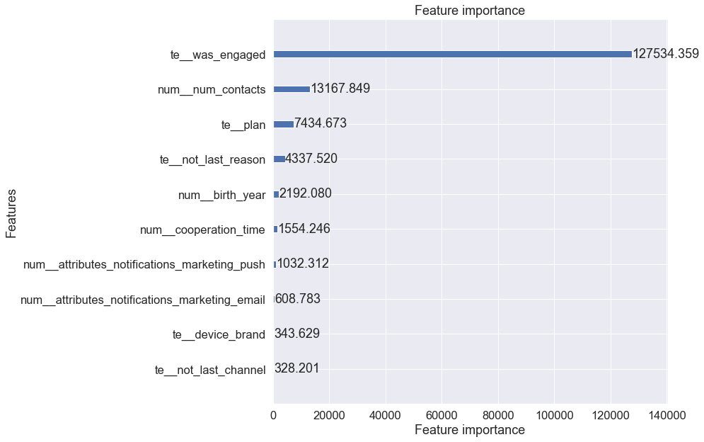

```python
fig, ax2 = plt.subplots(figsize=(10,10))

lgb.plot_importance(model, max_num_features=15, ax=ax2, importance_type = 'gain', )
```

```python
def calculate_AUC_prop(model, Xtrain, Xtest, ytrain, ytest):
    y_pred_train = model.predict_proba(Xtrain)[:,1]
    fpr_train, tpr_train, thresholds_train = metrics.roc_curve(ytrain, y_pred_train, pos_label=1)
    roc_auc_train = metrics.auc(fpr_train, tpr_train)
    print("Train AUC= %.3f"% roc_auc_train)

    y_pred_test = model.predict_proba(Xtest)[:,1]
    fpr_test, tpr_test, thresholds_test = metrics.roc_curve(ytest, y_pred_test, pos_label=1)
    roc_auc_test = metrics.auc(fpr_test, tpr_test)
    print("Test AUC= %.3f"% roc_auc_test)

    fig, ax = plt.subplots(figsize=(7,7))
    lw = 2
    ax.plot(fpr_train, tpr_train,  color='darkorange',
             lw=lw, label='Train ROC curve (area = %0.3f)' % roc_auc_train)
    ax.plot(fpr_test, tpr_test,  color='darkblue',
             lw=lw, label='Test ROC curve (area = %0.3f)' % roc_auc_test)
    ax.plot([0, 1], [0, 1], color='navy', lw=lw, linestyle='--')
    plt.xlim([0.0, 1.0])
    plt.ylim([0.0, 1.05])
    plt.xlabel('False Positive Rate')
    plt.ylabel('True Positive Rate')
    plt.title('Receiver operating characteristic')
    plt.legend(loc="lower right")
    plt.show

    return (roc_auc_train,roc_auc_test)
```

**Comment on model score:**  
Model score is 86 AUC (equivalent of 72 of Gini).

Only challenge is that that this feature (engagement from previous period) dominates others features.  
If we need more accurate model it worth it, but if we want to understand other factors that affect engagement it could be skipped.

```
Train AUC= 0.879
Test AUC= 0.861
```

```
(0.8785953069185938, 0.8613384542137724)
```

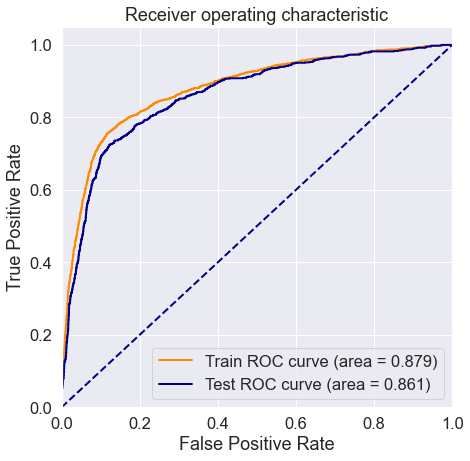

```python
calculate_AUC_prop(model,train_X_t, test_X_t, train_y, test_y)
```

# Observed correlations

Lift curve represent how much more likely is to guess correctly about customer engagement using model than doing it at random.

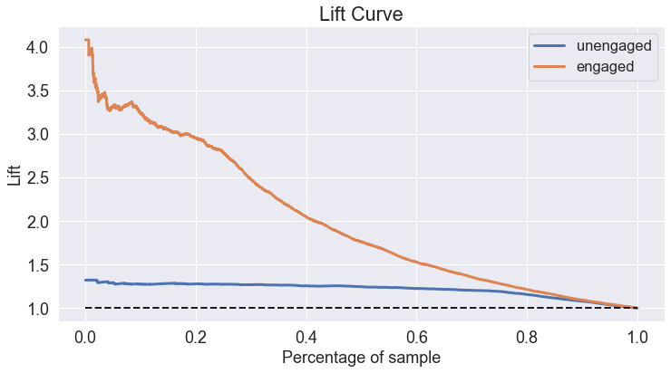

```python
import scikitplot as skplt

fig, ax1 = plt.subplots(figsize=(12,6))


skplt.metrics.plot_lift_curve(test_y, model.predict_proba(test_X_t), ax=ax1)
plt.legend(['unengaged','engaged'])
plt.show()
```

## Number of contact

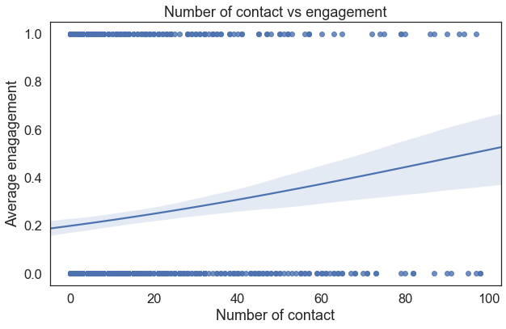

```python
sns.set(font_scale=1.5)
sns.set_style("white")


fig, ax1 = plt.subplots(figsize=(10,6))
ax = sns.regplot(x="num_contacts",
                 y="eng_use3lastweeks",
                 data=users.query("num_contacts<100").sample(1000,random_state=1),
                 truncate=False,
                 logistic=True, ax=ax1)

plt.title('Number of contact vs engagement')
plt.xlabel('Number of contact')
plt.ylabel('Average enagagement')
```

## Plan

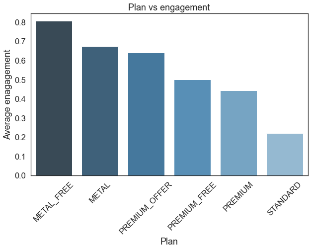

```python
sns.set(font_scale=1.5)
sns.set_style("white")

tmp = users.groupby('plan')[['eng_use3lastweeks']].mean().sort_values('eng_use3lastweeks', ascending=False).reset_index()

fig, ax1 = plt.subplots(figsize=(10,6))
g = sns.barplot(x="plan",
                 y="eng_use3lastweeks",
                 data=tmp,
                 palette="Blues_d",
                 ax=ax1)

ax1.set_xticklabels(ax1.get_xticklabels(), rotation=45)

plt.title('Plan vs engagement')
plt.xlabel('Plan')
plt.ylabel('Average enagagement')
```

## Last notyfiaction

It's looks like certain sms with promotions stimulate engagement a lot or only most engaged customers receive them. Hard to tell without more information.

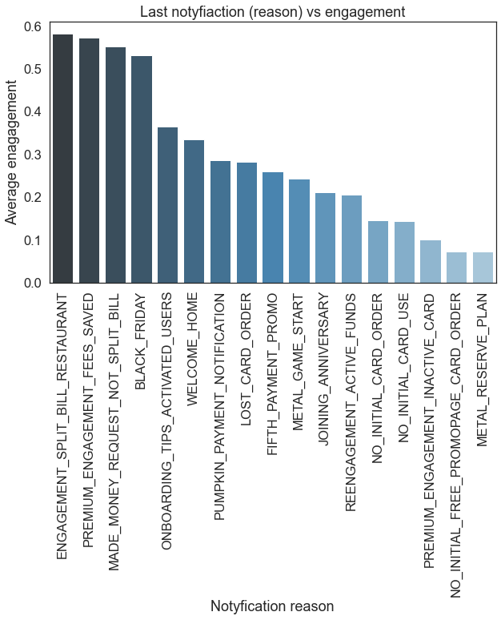

```python
sns.set(font_scale=1.5)
sns.set_style("white")

tmp = users.groupby('not_last_reason')[['eng_use3lastweeks']].mean().sort_values('eng_use3lastweeks', ascending=False).reset_index()

fig, ax1 = plt.subplots(figsize=(10,6))
g = sns.barplot(x="not_last_reason",
                 y="eng_use3lastweeks",
                 data=tmp,
                 palette="Blues_d",
                 ax=ax1)

ax1.set_xticklabels(ax1.get_xticklabels(), rotation=90)

plt.title('Last notyfiaction (reason) vs engagement')
plt.xlabel('Notyfication reason')
plt.ylabel('Average enagagement')
```

## Birth year

The younger client is, the more engaged.

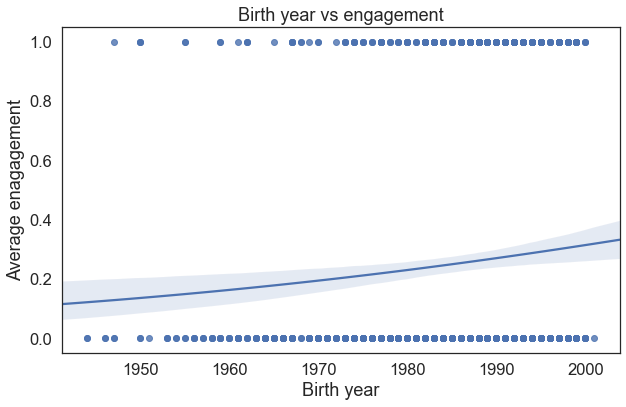

```python
sns.set(font_scale=1.5)
sns.set_style("white")


fig, ax1 = plt.subplots(figsize=(10,6))
ax = sns.regplot(x="birth_year",
                 y="eng_use3lastweeks",
                 data=users.query("birth_year>1900").sample(1000,random_state=1),
                 truncate=False,
                 logistic=True, ax=ax1)

plt.title('Birth year vs engagement')
plt.xlabel('Birth year')
plt.ylabel('Average enagagement')
```